# Ex 4

### Functional enrichment analysis

Installation of the new required packages:

```r
#install.packages("gProfileR")
#install.packages("knitr")
#BiocManager::install("gage")
```

Loading the required packages:

```r
library(compGenomRData)
library(DESeq2)
library(gProfileR)
library(gage)
```

Loading the data:

```r
counts_file <- system.file("extdata/rna-seq/SRP029880.raw_counts.tsv",
                           package = "compGenomRData")
coldata_file <- system.file("extdata/rna-seq/SRP029880.colData.tsv",
                            package = "compGenomRData")
counts <- as.matrix(read.table(counts_file, header = T, sep = '\t'))

#remove the 'width' column
countData <- as.matrix(subset(counts, select = c(-width)))

#define the experimental setup
colData <- read.table(coldata_file, header = T, sep = '\t',
                      stringsAsFactors = TRUE)

#define the design formula
designFormula <- "~ group"

#create a DESeq dataset object from the count matrix and the colData
dds <- DESeqDataSetFromMatrix(countData = countData,
                              colData = colData,
                              design = as.formula(designFormula))
dds <- DESeq(dds)

DEresults = results(dds, contrast = c("group", 'CASE', 'CTRL'))
```

Let’s select the genes that are significantly differentially expressed between the case and control samples. Let’s extract genes that have an adjusted p-value below 0.1 and that show a 2-fold change (either negative or positive) in the case compared to control. We will then feed this gene set into the gProfileR function.

```r
#remove genes with NA values
DE <- DEresults[!is.na(DEresults$padj),]

#select genes with adjusted p-values below 0.1
DE <- DE[DE$padj < 0.1,]

#select genes with absolute log2 fold change above 1 (two-fold change)
DE <- DE[abs(DE$log2FoldChange) > 1,]

#get the list of genes of interest
genesOfInterest <- rownames(DE)

#calculate enriched GO terms
goResults <- gprofiler(query = genesOfInterest,
                       organism = 'hsapiens',
                       src_filter = 'GO',
                       hier_filtering = 'moderate')
```

##### 1.

Re-run gProfileR, this time using pathway annotations such as KEGG, REACTOME, and protein complex databases such as CORUM, in addition to the GO terms. Sort the resulting tables by columns `precision` and/or `recall`. How do the top GO terms change when sorted for `precision`, `recall`, or `p.value`? hint: use `order()` for sorting. [Difficulty: **Beginner**]

```r
keggResults <- gprofiler(query = genesOfInterest,
                       organism = 'hsapiens',
                       src_filter = 'KEGG',
                       hier_filtering = 'moderate')
reactomeResults <- gprofiler(query = genesOfInterest,
                       organism = 'hsapiens',
                       src_filter = 'REAC',
                       hier_filtering = 'moderate')
corumResults <- gprofiler(query = genesOfInterest,
                       organism = 'hsapiens',
                       src_filter = 'CORUM',
                       hier_filtering = 'moderate')
goResults.per <- goResults[order(goResults$precision),]
goResults.re <- goResults[order(goResults$recall),]
goResults.p.value <- goResults[order(goResults$p.value),]
```

הנתונים עצמם אינם משתנים, אך הסדר המופיע משתנה.

#### Gene set enrichment analysis

We use the bioconductor package gage to demonstrate how to do GSEA using normalized expression data of the samples as input.

```r
#Let's define the first gene set as the list of genes from one of the
#significant GO terms found in the GO analysis. order go results by pvalue
goResults <- goResults[order(goResults$p.value),]

#restrict the terms that have at most 100 genes overlapping with the query
go <- goResults[goResults$overlap.size < 100,]

# use the top term from this table to create a gene set
geneSet1 <- unlist(strsplit(go[1,]$intersection, ','))

#Define another gene set by just randomly selecting 25 genes from the counts
#table get normalized counts from DESeq2 results
normalizedCounts <- DESeq2::counts(dds, normalized = TRUE)

geneSet2 <- sample(rownames(normalizedCounts), 25)

geneSets <- list('top_GO_term' = geneSet1,
                 'random_set' = geneSet2)

# Using the defined gene sets, we’d like to do a group comparison between the case
# samples with respect to the control samples.

#Use the normalized counts to carry out a GSEA.
gseaResults <- gage(exprs = log2(normalizedCounts+1),
                    ref = match(rownames(colData[colData$group =='CTRL',]),
                                colnames(normalizedCounts)),
                    samp = match(rownames(colData[colData$group == 'CASE',]),
                                 colnames(normalizedCounts)),
                    gsets = geneSets,
                    compare = 'as.group')
```

##### 2.

Repeat the gene set enrichment analysis by trying different options for the `compare` argument of the `GAGE:gage` function. How do the results differ? [Difficulty: **Beginner**]

```r
gseaResults.paired <- gage(exprs = log2(normalizedCounts+1),
                    ref = match(rownames(colData[colData$group =='CTRL',]),
                                colnames(normalizedCounts)),
                    samp = match(rownames(colData[colData$group == 'CASE',]),
                                 colnames(normalizedCounts)),
                    gsets = geneSets,
                    compare = 'paired')

gseaResults.unpaired <- gage(exprs = log2(normalizedCounts+1),
                    ref = match(rownames(colData[colData$group =='CTRL',]),
                                colnames(normalizedCounts)),
                    samp = match(rownames(colData[colData$group == 'CASE',]),
                                 colnames(normalizedCounts)),
                    gsets = geneSets,
                    compare = 'unpaired')

gseaResults.1ongroup <- gage(exprs = log2(normalizedCounts+1),
                    ref = match(rownames(colData[colData$group =='CTRL',]),
                                colnames(normalizedCounts)),
                    samp = match(rownames(colData[colData$group == 'CASE',]),
                                 colnames(normalizedCounts)),
                    gsets = geneSets,
                    compare = '1ongroup')
```

The comparison scheme is changed, and therefore the results are different.

##### 3.

Make a scatter plot of GO term sizes and obtained p-values by setting the `gProfiler::gprofiler` argument `significant = FALSE`. Is there a correlation of term sizes and p-values? (Hint: Take -log10 of p-values). If so, how can this bias be mitigated? [Difficulty: **Intermediate**]

```r
goResultsF <- gprofiler(query = genesOfInterest,
                       organism = 'hsapiens',
                       src_filter = 'GO',
                       hier_filtering = 'moderate',
                       significant = FALSE)
```

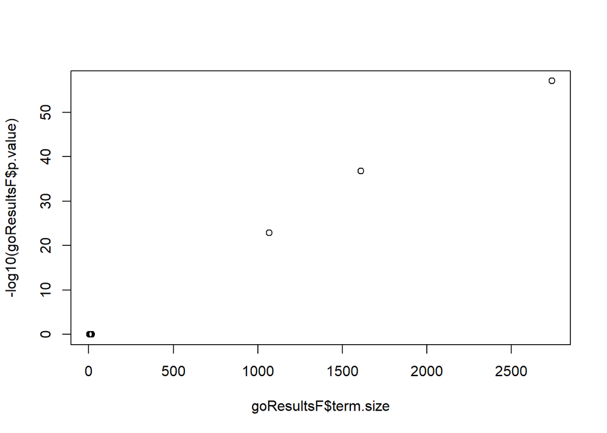

```r
plot(goResultsF$term.size,-log10(goResultsF$p.value))
```

There is a correlation between them.

##### 4.

Do a gene-set enrichment analysis using gene sets from top 10 GO terms. [Difficulty: **Intermediate**]

```r
geneSet10 <- strsplit(go[1:10,]$intersection, ',')

# Use the normalized counts to carry out a GSEA.
gseaResults10 <- gage(exprs = log2(normalizedCounts+1),
                    ref = match(rownames(colData[colData$group =='CTRL',]),
                                colnames(normalizedCounts)),
                    samp = match(rownames(colData[colData$group == 'CASE',]),
                                 colnames(normalizedCounts)),
                    gsets = geneSet10,
                    compare = 'as.group')
```

##### 5.

What are the other available R packages that can carry out gene set enrichment analysis for RNA-seq datasets? [Difficulty: **Intermediate**]

clusterProfiler and Pathview for example.

##### 6.

Use the topGO package (https://bioconductor.org/packages/release/bioc/html/topGO.html) to re-do the GO term analysis. Compare and contrast the results with what has been obtained using the `gProfileR` package. Which tool is faster, `gProfileR` or topGO? Why? [Difficulty: **Advanced**] topGO is faster, but it wasn’t easy making it work. since everything is already there- just awaits to be used.

```r
library(topGO)
browseVignettes("topGO")
```

```
## starting httpd help server ...
```

```
##  done
```

```r
res <- DE
geneList = as.vector(res$pvalue)
#geneList =  factor(as.vector(as.integer(res$pvalue)),levels = as.vector(1:2))
names(geneList) <- rownames(res)
library("AnnotationDbi")
library("org.Hs.eg.db")
```

```r
topDiffGenes <- function(allScore) {return(allScore < 0.01)}

allGO2genes <- annFUN.org(whichOnto="BP", feasibleGenes=NULL, mapping="org.Hs.eg.db", ID="symbol")


sampleGOdata <- new("topGOdata",
                    description = "Doing TopGO",
                    ontology = "BP",
                    allGenes = geneList,
                    geneSel = topDiffGenes,
                    annot = annFUN.GO2genes, GO2genes=allGO2genes,
                    nodeSize=10)
```

```
##
## Building most specific GOs .....
```

```
##  ( 7689 GO terms found. )
```

```
##
## Build GO DAG topology ..........
```

```
##  ( 11792 GO terms and 26873 relations. )
```

```
##
## Annotating nodes ...............
```

```
##  ( 3763 genes annotated to the GO terms. )
```

```r
resultFisher <- runTest(sampleGOdata, algorithm = "classic", statistic = "fisher")
```

```
##
##           -- Classic Algorithm --
##
##       the algorithm is scoring 3470 nontrivial nodes
##       parameters:
##           test statistic: fisher
```

```r
resultKS <- runTest(sampleGOdata, algorithm = "classic", statistic = "ks")
```

```
##
##           -- Classic Algorithm --
##
##       the algorithm is scoring 3470 nontrivial nodes
##       parameters:
##           test statistic: ks
##           score order: increasing
```

```r
resultKS.elim <- runTest(sampleGOdata, algorithm = "elim", statistic = "ks")
```

```
##
##           -- Elim Algorithm --
##
##       the algorithm is scoring 3470 nontrivial nodes
##       parameters:
##           test statistic: ks
##           cutOff: 0.01
##           score order: increasing
```

[output not shown]

[output not shown]

[output not shown]

[output not shown]

[output not shown]

[output not shown]

[output not shown]

[output not shown]

[output not shown]

[output not shown]

[output not shown]

[output not shown]

[output not shown]

[output not shown]

[output not shown]

[output not shown]

[output not shown]

[output not shown]

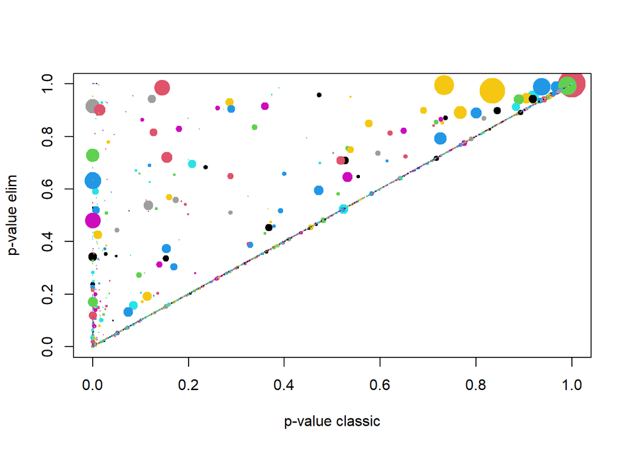

```r
allRes <- GenTable(sampleGOdata,
                    classicFisher = resultFisher,
                    classicKS = resultKS,
                    elimKS = resultKS.elim,
                    orderBy = "elimKS",
                    ranksOf = "classicFisher",
                    topNodes = 10)
pValue.classic <- score(resultKS)
pValue.elim <- score(resultKS.elim)[names(pValue.classic)]
gstat <- termStat(sampleGOdata, names(pValue.classic))
gSize <- gstat$Annotated / max(gstat$Annotated) * 4
gCol <- gstat$Significant

plot(pValue.classic,
     pValue.elim,
     xlab = "p-value classic",
     ylab = "p-value elim",
     pch = 19,
     cex = gSize,
     col = gCol)
```

```r
sel.go <- names(pValue.classic)[pValue.elim < pValue.classic]
cbind(termStat(sampleGOdata, sel.go),elim = pValue.elim[sel.go],classic = pValue.classic[sel.go])
```

|  | Annotated | Significant | Expected | elim | classic |
| --- | --- | --- | --- | --- | --- |
| GO:0048732 | 145 | 134 | 130.78 | 0.03807305 | 0.04692961 |

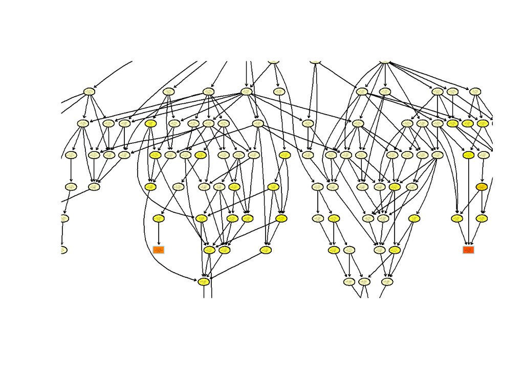

```
## $dag
## A graphNEL graph with directed edges
## Number of Nodes = 110
## Number of Edges = 222
##
## $complete.dag
## [1] "A graph with 110 nodes."
```

```r
showSigOfNodes(sampleGOdata, score(resultKS.elim), firstSigNodes = 5, useInfo = 'all')
```

##### 7.

Given a gene set annotated for human, how can it be utilized to work on *C. elegans* data? (Hint: See `biomaRt::getLDS`). [Difficulty: **Advanced**]

```r
library(biomaRt)
human = useMart("ensembl", dataset = "hsapiens_gene_ensembl")
c.elegans = useMart("ensembl", dataset = "celegans_gene_ensembl")

getLDS(attributes = c("hgnc_symbol","chromosome_name", "start_position"), filters = "hgnc_symbol", values = "TP53", mart = human,
       attributesL = c("chromosome_name","start_position"), martL = c.elegans)
```

| HGNC.symbol | Chromosome.scaffold.name | Gene.start..bp. | Chromosome.scaffold.name.1 | Gene.start..bp..1 |
| --- | --- | --- | --- | --- |

##### 8.

Import curated pathway gene sets with Entrez identifiers from the [MSIGDB database](http://software.broadinstitute.org/gsea/msigdb/collections.jsp) and re-do the GSEA for all curated gene sets. [Difficulty: **Advanced**]

```r
library(msigdbr)
c2 <- msigdbr(species = "Homo sapiens", category = "C2")

geneSet.c2 <- as.list(c2$human_gene_symbol)

c2.gseaResults <- gage(exprs = log2(normalizedCounts+1),
                    ref = match(rownames(colData[colData$group =='CTRL',]),
                                colnames(normalizedCounts)),
                    samp = match(rownames(colData[colData$group == 'CASE',]),
                                 colnames(normalizedCounts)),
                    gsets = geneSet.c2,
                    compare = 'as.group')
```